# Convolutional Neural Networks

## Project: Write an Algorithm for Landmark Classification

In this notebook, some template code has already been provided for you, and you will need to implement additional functionality to successfully complete this project. You will not need to modify the included code beyond what is requested. Sections that begin with **'(IMPLEMENTATION)'** in the header indicate that the following block of code will require additional functionality which you must provide. Instructions will be provided for each section, and the specifics of the implementation are marked in the code block with a 'TODO' statement. Please be sure to read the instructions carefully!

> **Note**: Once you have completed all the code implementations, you need to finalize your work by exporting the Jupyter Notebook as an HTML document. Before exporting the notebook to HTML, all the code cells need to have been run so that reviewers can see the final implementation and output. You can then export the notebook by using the menu above and navigating to **File -> Download as -> HTML (.html)**. Include the finished document along with this notebook as your submission.

In addition to implementing code, there will be questions that you must answer which relate to the project and your implementation. Each section where you will answer a question is preceded by a **'Question X'** header. Carefully read each question and provide thorough answers in the following text boxes that begin with **'Answer:'**. Your project submission will be evaluated based on your answers to each of the questions and the implementation you provide.

> **Note:** Code and Markdown cells can be executed using the **Shift + Enter** keyboard shortcut. Markdown cells can be edited by double-clicking the cell to enter edit mode.

The rubric contains *optional* "Stand Out Suggestions" for enhancing the project beyond the minimum requirements. If you decide to pursue the "Stand Out Suggestions", you should include the code in this Jupyter notebook.

### Why We're Here

Photo sharing and photo storage services like to have location data for each photo that is uploaded. With the location data, these services can build advanced features, such as automatic suggestion of relevant tags or automatic photo organization, which help provide a compelling user experience. Although a photo's location can often be obtained by looking at the photo's metadata, many photos uploaded to these services will not have location metadata available. This can happen when, for example, the camera capturing the picture does not have GPS or if a photo's metadata is scrubbed due to privacy concerns.

If no location metadata for an image is available, one way to infer the location is to detect and classify a discernible landmark in the image. Given the large number of landmarks across the world and the immense volume of images that are uploaded to photo sharing services, using human judgement to classify these landmarks would not be feasible.

In this notebook, you will take the first steps towards addressing this problem by building models to automatically predict the location of the image based on any landmarks depicted in the image. At the end of this project, your code will accept any user-supplied image as input and suggest the top k most relevant landmarks from 50 possible landmarks from across the world. The image below displays a potential sample output of your finished project.

[figure not shown]

### The Road Ahead

We break the notebook into separate steps. Feel free to use the links below to navigate the notebook.

- Step 0: Download Datasets and Install Python Modules
- Step 1: Create a CNN to Classify Landmarks (from Scratch)
- Step 2: Create a CNN to Classify Landmarks (using Transfer Learning)
- Step 3: Write Your Landmark Prediction Algorithm

## Step 0: Download Datasets and Install Python Modules

**Note: if you are using the Udacity workspace, *YOU CAN SKIP THIS STEP*. The dataset can be found in the `/data` folder and all required Python modules have been installed in the workspace.**

Download the [landmark dataset](https://udacity-dlnfd.s3-us-west-1.amazonaws.com/datasets/landmark_images.zip). Unzip the folder and place it in this project's home directory, at the location `/landmark_images`.

Install the following Python modules:

- cv2
- matplotlib
- numpy
- PIL
- torch
- torchvision

## Step 1: Create a CNN to Classify Landmarks (from Scratch)

In this step, you will create a CNN that classifies landmarks. You must create your CNN *from scratch* (so, you can't use transfer learning *yet*!), and you must attain a test accuracy of at least 20%.

Although 20% may seem low at first glance, it seems more reasonable after realizing how difficult of a problem this is. Many times, an image that is taken at a landmark captures a fairly mundane image of an animal or plant, like in the following picture.

[figure not shown]

Just by looking at that image alone, would you have been able to guess that it was taken at the Haleakalā National Park in Hawaii?

An accuracy of 20% is significantly better than random guessing, which would provide an accuracy of just 2%. In Step 2 of this notebook, you will have the opportunity to greatly improve accuracy by using transfer learning to create a CNN.

Remember that practice is far ahead of theory in deep learning. Experiment with many different architectures, and trust your intuition. And, of course, have fun!

### (IMPLEMENTATION) Specify Data Loaders for the Landmark Dataset

Use the code cell below to create three separate [data loaders](http://pytorch.org/docs/stable/data.html#torch.utils.data.DataLoader): one for training data, one for validation data, and one for test data. Randomly split the images located at `landmark_images/train` to create the train and validation data loaders, and use the images located at `landmark_images/test` to create the test data loader.

All three of your data loaders should be accessible via a dictionary named `loaders_scratch`. Your train data loader should be at `loaders_scratch['train']`, your validation data loader should be at `loaders_scratch['valid']`, and your test data loader should be at `loaders_scratch['test']`.

You may find [this documentation on custom datasets](https://pytorch.org/docs/stable/torchvision/datasets.html#datasetfolder) to be a useful resource. If you are interested in augmenting your training and/or validation data, check out the wide variety of [transforms](http://pytorch.org/docs/stable/torchvision/transforms.html?highlight=transform)!

```python
import torch
import torchvision
import numpy as np

from torch import nn, optim
from torch.nn import functional as F
```

```python
from torchvision import transforms as T
from torch.utils.data import DataLoader
from torch.utils.data.sampler import SubsetRandomSampler

# p_validate -> percentage of training dataset that will be part of the validation dataset
def train_validation_split(train_dataset_size, p_validate=0.1):
    indices_arr = np.arange(train_dataset_size)
    np.random.shuffle(indices_arr)

    total_validation = int(np.floor(train_dataset_size * p_validate))

    # first total_validation indices are for the validation loader, rest for the training loader
    return indices_arr[total_validation:], indices_arr[:total_validation]


### TODO: Write data loaders for training, validation, and test sets
## Specify appropriate transforms, and batch_sizes

train_transform = T.Compose([
    T.Resize(size=(256,256)),
    #T.RandomHorizontalFlip(),
    #T.RandomRotation(10),
    T.ToTensor(),
    T.Normalize((0.5, 0.5, 0.5), (0.5, 0.5, 0.5))
])

test_transform = T.Compose([
    T.Resize(size=(256,256)),
    T.ToTensor(),
    T.Normalize((0.5, 0.5, 0.5), (0.5, 0.5, 0.5))
])

train_dataset = torchvision.datasets.ImageFolder('./data/landmark_images/train', transform=train_transform)
test_dataset = torchvision.datasets.ImageFolder('./data/landmark_images/test', transform=test_transform)

train_idx, validation_idx = train_validation_split(len(train_dataset))
train_sampler = SubsetRandomSampler(train_idx)
valid_sampler = SubsetRandomSampler(validation_idx)

train_loader = DataLoader(train_dataset, batch_size=32, sampler=train_sampler)
valid_loader = DataLoader(train_dataset, batch_size=32, sampler=valid_sampler)
test_loader = DataLoader(test_dataset, batch_size=32, shuffle=True)

loaders_scratch = {'train': train_loader, 'valid': valid_loader, 'test': test_loader}
```

**Question 1:** Describe your chosen procedure for preprocessing the data.

- How does your code resize the images (by cropping, stretching, etc)? What size did you pick for the input tensor, and why?
- Did you decide to augment the dataset? If so, how (through translations, flips, rotations, etc)? If not, why not?

**Answer**:

- I decided to resize my images to a square matrix of dimensions 256X256, as I believe having a matrix with dimensions that are powers of 2 works well with the CNN and 256 sounds like a good size for the images.
- Most of pictures that need to be classified are likely to be taken from a mobile phone. This means that there is a high probability that the pictures could be taken in non-standard ways, like being taken horizontially flipped or with an angle. Therefore, I have decided to augment the data using the following transforms:
  - RandomHorizontalFlip, which randomly flips the image horizontally with probability of 0.5
  - RandomRotation, it randomly rotates the image between -10 and 10 degrees

However, after working with the project for a bit longer, I realized that the above additions were not that necessary to get high enough accuracies and I decided to not apply them anymore (by commenting them out).

### (IMPLEMENTATION) Visualize a Batch of Training Data

Use the code cell below to retrieve a batch of images from your train data loader, display at least 5 images simultaneously, and label each displayed image with its class name (e.g., "Golden Gate Bridge").

Visualizing the output of your data loader is a great way to ensure that your data loading and preprocessing are working as expected.

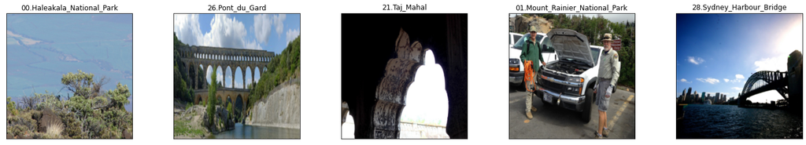

```python
import matplotlib.pyplot as plt
%matplotlib inline

def imshow(img):
    img = img / 2 + 0.5  # unnormalize
    plt.imshow(np.transpose(img, (1, 2, 0)))  # convert from Tensor image

## TODO: visualize a batch of the train data loader

## the class names can be accessed at the `classes` attribute
## of your dataset object (e.g., `train_dataset.classes`)
dataiter = iter(loaders_scratch['train'])
images, labels = dataiter.next()
images = images.numpy() # convert images to numpy for display

# plot the images in the batch, along with the corresponding labels
fig = plt.figure(figsize=(25, 4))
# display 5 images
for idx in np.arange(5):
    ax = fig.add_subplot(1, 5, idx+1, xticks=[], yticks=[])
    imshow(images[idx])
    ax.set_title(train_dataset.classes[labels[idx].item()])
```

### Initialize use_cuda variable

```python
# useful variable that tells us whether we should use the GPU
use_cuda = torch.cuda.is_available()
```

### (IMPLEMENTATION) Specify Loss Function and Optimizer

Use the next code cell to specify a [loss function](http://pytorch.org/docs/stable/nn.html#loss-functions) and [optimizer](http://pytorch.org/docs/stable/optim.html). Save the chosen loss function as `criterion_scratch`, and fill in the function `get_optimizer_scratch` below.

```python
## TODO: select loss function
criterion_scratch = nn.CrossEntropyLoss()

def get_optimizer_scratch(model):
    ## TODO: select and return an optimizer
    return optim.SGD(model.parameters(), lr=0.01)
```

### (IMPLEMENTATION) Model Architecture

Create a CNN to classify images of landmarks. Use the template in the code cell below.

```python
import torch.nn as nn

# define the CNN architecture
class Net(nn.Module):
    ## TODO: choose an architecture, and complete the class
    def __init__(self):
        super(Net, self).__init__()

        out_classes_len = 50

        ## Define layers of a CNN
        self.conv1 = nn.Conv2d(3, 32, 3, padding=1)
        self.conv2 = nn.Conv2d(32, 64, 3, padding=1)
        self.conv3 = nn.Conv2d(64, 128, 3, padding=1)
        self.conv4 = nn.Conv2d(128, 256, 3, padding=1)

        self.pooling = nn.MaxPool2d(2, stride=2)

        self.fc1 = nn.Linear(256 * 16 * 16, 256 * 8)
        self.fc2 = nn.Linear(256 * 8, out_classes_len)
        #self.fc3 = nn.Linear(256, out_classes_len)

        self.dropout = nn.Dropout(0.3)

    def forward(self, x):
        ## Define forward behavior
        x = self.pooling(F.relu(self.conv1(x))) # (3, 256, 256) -> (32, 128, 128)
        x = self.pooling(F.relu(self.conv2(x))) # (32, 128, 128) -> (64, 64, 64)
        x = self.pooling(F.relu(self.conv3(x))) # (64, 64, 64) -> (128, 32, 32)
        x = self.pooling(F.relu(self.conv4(x))) # (128, 32, 32) -> (256, 16, 16)

        x = x.view(-1, 256 * 16 * 16) #x = x.view(-1, 64 * 32 * 32)
        x = self.dropout(x)

        x = self.dropout(F.relu(self.fc1(x)))
        x = self.fc2(x)

        return x

#-#-# Do NOT modify the code below this line. #-#-#

# instantiate the CNN
model_scratch = Net()

# move tensors to GPU if CUDA is available
if use_cuda:
    model_scratch.cuda()
```

**Question 2:** Outline the steps you took to get to your final CNN architecture and your reasoning at each step.

As soon as I am done with the visual processing part of the net, I am converting the output of the final (related to image processing) layer to a 1-dimensional vector and I am feeding it to 2 fully connected layers, the first of which is using the ReLU activation function and the 2nd one just spits out numerical values, which are being used by the loss function (cross-entropy) to calculate the output vector in the appropriate way (ie. the output values to sum up to 1). The reason that I sticked to only 1 hidden layer is that, in my experience with working with neural networks so far, adding more hidden layers doesn't add much to the overall performance of the architecture and I decided to apply that in our case as well.

For the fc layers, I am using randomized dropouts (with dropout probability of 30%) to tackle potential overfitting issues that could arise when training the network.

### (IMPLEMENTATION) Implement the Training Algorithm

Implement your training algorithm in the code cell below. [Save the final model parameters](http://pytorch.org/docs/master/notes/serialization.html) at the filepath stored in the variable `save_path`.

```python
def train(n_epochs, loaders, model, optimizer, criterion, use_cuda, save_path):
    """returns trained model"""
    # initialize tracker for minimum validation loss
    valid_loss_min = np.Inf

    for epoch in range(1, n_epochs+1):
        # initialize variables to monitor training and validation loss
        train_loss = 0.0
        valid_loss = 0.0

        valid_iter = iter(loaders['valid'])

        ###################
        # train the model #
        ###################
        # set the module to training mode
        model.train()
        for batch_idx, (data, target) in enumerate(loaders['train']):
            # move to GPU
            if use_cuda:
                data, target = data.cuda(), target.cuda()

            ## TODO: find the loss and update the model parameters accordingly
            ## record the average training loss, using something like
            ## train_loss = train_loss + ((1 / (batch_idx + 1)) * (loss.data.item() - train_loss))
            optimizer.zero_grad()

            output = model(data)
            loss = criterion(output, target)

            loss.backward()
            optimizer.step()

            train_loss += 1 / (batch_idx + 1) * (loss.data.item() - train_loss)



        ######################
        # validate the model #
        ######################
        # set the model to evaluation mode
        model.eval()
        for batch_idx, (data, target) in enumerate(loaders['valid']):
            # move to GPU
            if use_cuda:
                data, target = data.cuda(), target.cuda()

            ## TODO: update average validation loss
            output = model(data)
            loss = criterion(output, target)

            valid_loss += 1 / (batch_idx + 1) * (loss.data.item() - valid_loss)

        # print training/validation statistics
        print('Epoch: {} \tTraining Loss: {:.6f} \tValidation Loss: {:.6f}'.format(
            epoch,
            train_loss,
            valid_loss
            ))

        ## TODO: if the validation loss has decreased, save the model at the filepath stored in save_path
        if valid_loss < valid_loss_min:
            valid_loss_min = valid_loss

            torch.save(model.state_dict(), save_path)



    return model
```

### (IMPLEMENTATION) Experiment with the Weight Initialization

Use the code cell below to define a custom weight initialization, and then train with your weight initialization for a few epochs. Make sure that neither the training loss nor validation loss is `nan`.

Later on, you will be able to see how this compares to training with PyTorch's default weight initialization.

```python
def custom_weight_init(m):
    ## TODO: implement a weight initialization strategy

    # I am assigning the weights to random values drawn from a uniform distribution
    # between [-1 / sqrt(nodes_len), 1 / sqrt(nodes_len)]

    classname = m.__class__.__name__

    # (apply only to linear layers)
    if classname.find('Linear') != -1:
        n = m.in_features
        y = 1.0/np.sqrt(n)
        m.weight.data.uniform_(-y, y)
        m.bias.data.fill_(0)

#-#-# Do NOT modify the code below this line. #-#-#

model_scratch.apply(custom_weight_init)
model_scratch = train(20, loaders_scratch, model_scratch, get_optimizer_scratch(model_scratch),
                      criterion_scratch, use_cuda, 'ignore.pt')
```

[output not shown]

### (IMPLEMENTATION) Train and Validate the Model

Run the next code cell to train your model.

```python
## TODO: you may change the number of epochs if you'd like,
## but changing it is not required
num_epochs = 15

#-#-# Do NOT modify the code below this line. #-#-#

# function to re-initialize a model with pytorch's default weight initialization
def default_weight_init(m):
    reset_parameters = getattr(m, 'reset_parameters', None)
    if callable(reset_parameters):
        m.reset_parameters()

# reset the model parameters
model_scratch.apply(default_weight_init)

# train the model
model_scratch = train(num_epochs, loaders_scratch, model_scratch, get_optimizer_scratch(model_scratch),
                      criterion_scratch, use_cuda, 'model_scratch.pt')
```

```
Epoch: 1 	Training Loss: 3.910251 	Validation Loss: 3.906769
Epoch: 2 	Training Loss: 3.894942 	Validation Loss: 3.876971
Epoch: 3 	Training Loss: 3.836199 	Validation Loss: 3.797478
Epoch: 4 	Training Loss: 3.742654 	Validation Loss: 3.719064
Epoch: 5 	Training Loss: 3.632269 	Validation Loss: 3.618813
Epoch: 6 	Training Loss: 3.529540 	Validation Loss: 3.529535
Epoch: 7 	Training Loss: 3.412674 	Validation Loss: 3.494986
Epoch: 8 	Training Loss: 3.254444 	Validation Loss: 3.319192
Epoch: 9 	Training Loss: 3.135703 	Validation Loss: 3.232408
Epoch: 10 	Training Loss: 3.022906 	Validation Loss: 3.123918
Epoch: 11 	Training Loss: 2.884165 	Validation Loss: 3.253674
Epoch: 12 	Training Loss: 2.734569 	Validation Loss: 3.170974
Epoch: 13 	Training Loss: 2.560364 	Validation Loss: 3.129268
Epoch: 14 	Training Loss: 2.348467 	Validation Loss: 3.113605
Epoch: 15 	Training Loss: 2.074853 	Validation Loss: 3.387043
```

### (IMPLEMENTATION) Test the Model

Run the code cell below to try out your model on the test dataset of landmark images. Run the code cell below to calculate and print the test loss and accuracy. Ensure that your test accuracy is greater than 20%.

```python
def test(loaders, model, criterion, use_cuda):

    # monitor test loss and accuracy
    test_loss = 0.
    correct = 0.
    total = 0.

    # set the module to evaluation mode
    model.eval()

    for batch_idx, (data, target) in enumerate(loaders['test']):
        # move to GPU
        if use_cuda:
            data, target = data.cuda(), target.cuda()
        # forward pass: compute predicted outputs by passing inputs to the model
        output = model(data)
        # calculate the loss
        loss = criterion(output, target)
        # update average test loss
        test_loss = test_loss + ((1 / (batch_idx + 1)) * (loss.data.item() - test_loss))
        # convert output probabilities to predicted class
        pred = output.data.max(1, keepdim=True)[1]
        # compare predictions to true label
        correct += np.sum(np.squeeze(pred.eq(target.data.view_as(pred))).cpu().numpy())
        total += data.size(0)

    print('Test Loss: {:.6f}\n'.format(test_loss))

    print('\nTest Accuracy: %2d%% (%2d/%2d)' % (
        100. * correct / total, correct, total))

# load the model that got the best validation accuracy
model_scratch.load_state_dict(torch.load('model_scratch.pt'))
test(loaders_scratch, model_scratch, criterion_scratch, use_cuda)
```

```
Test Loss: 3.059450


Test Accuracy: 24% (311/1250)
```

## Step 2: Create a CNN to Classify Landmarks (using Transfer Learning)

You will now use transfer learning to create a CNN that can identify landmarks from images. Your CNN must attain at least 60% accuracy on the test set.

### (IMPLEMENTATION) Specify Data Loaders for the Landmark Dataset

Use the code cell below to create three separate [data loaders](http://pytorch.org/docs/stable/data.html#torch.utils.data.DataLoader): one for training data, one for validation data, and one for test data. Randomly split the images located at `landmark_images/train` to create the train and validation data loaders, and use the images located at `landmark_images/test` to create the test data loader.

All three of your data loaders should be accessible via a dictionary named `loaders_transfer`. Your train data loader should be at `loaders_transfer['train']`, your validation data loader should be at `loaders_transfer['valid']`, and your test data loader should be at `loaders_transfer['test']`.

If you like, **you are welcome to use the same data loaders from the previous step**, when you created a CNN from scratch.

```python
### TODO: Write data loaders for training, validation, and test sets
## Specify appropriate transforms, and batch_sizes

train_transform = T.Compose([
    T.Resize(size=(256,256)),
    #T.RandomHorizontalFlip(),
    #T.RandomRotation(10),
    T.ToTensor(),
    T.Normalize((0.5, 0.5, 0.5), (0.5, 0.5, 0.5))
])

test_transform = T.Compose([
    T.Resize(size=(256,256)),
    T.ToTensor(),
    T.Normalize((0.5, 0.5, 0.5), (0.5, 0.5, 0.5))
])

train_dataset = torchvision.datasets.ImageFolder('./data/landmark_images/train', transform=train_transform)
test_dataset = torchvision.datasets.ImageFolder('./data/landmark_images/test', transform=test_transform)

train_idx, validation_idx = train_validation_split(len(train_dataset))
train_sampler = SubsetRandomSampler(train_idx)
valid_sampler = SubsetRandomSampler(validation_idx)

train_loader = DataLoader(train_dataset, batch_size=32, sampler=train_sampler)
valid_loader = DataLoader(train_dataset, batch_size=32, sampler=valid_sampler)
test_loader = DataLoader(test_dataset, batch_size=32, shuffle=True)

loaders_transfer = {'train': train_loader, 'valid': valid_loader, 'test': test_loader}
```

### (IMPLEMENTATION) Specify Loss Function and Optimizer

Use the next code cell to specify a [loss function](http://pytorch.org/docs/stable/nn.html#loss-functions) and [optimizer](http://pytorch.org/docs/stable/optim.html). Save the chosen loss function as `criterion_transfer`, and fill in the function `get_optimizer_transfer` below.

```python
## TODO: select loss function
criterion_transfer = nn.CrossEntropyLoss()

def get_optimizer_transfer(model):
    ## TODO: select and return an optimizer
    return optim.SGD(model.parameters(), lr=0.01)
```

### (IMPLEMENTATION) Model Architecture

Use transfer learning to create a CNN to classify images of landmarks. Use the code cell below, and save your initialized model as the variable `model_transfer`.

```python
## TODO: Specify model architecture

model_transfer = torchvision.models.vgg19(pretrained=True)

# Freeze training for all "features" layers
for param in model_transfer.features.parameters():
    param.requires_grad = False

## add a last linear layer  that maps n_inputs -> 50 output classes
final_in = model_transfer.classifier[3].out_features

finalLayer = nn.Linear(final_in, 50)

model_transfer.classifier[6] = finalLayer
print('Final form of the model_transfer:', model_transfer)

#-#-# Do NOT modify the code below this line. #-#-#

if use_cuda:
    model_transfer = model_transfer.cuda()
```

```
Final form of the model_transfer: VGG(
  (features): Sequential(
    (0): Conv2d(3, 64, kernel_size=(3, 3), stride=(1, 1), padding=(1, 1))
    (1): ReLU(inplace=True)
    (2): Conv2d(64, 64, kernel_size=(3, 3), stride=(1, 1), padding=(1, 1))
    (3): ReLU(inplace=True)
    (4): MaxPool2d(kernel_size=2, stride=2, padding=0, dilation=1, ceil_mode=False)
    (5): Conv2d(64, 128, kernel_size=(3, 3), stride=(1, 1), padding=(1, 1))
    (6): ReLU(inplace=True)
    (7): Conv2d(128, 128, kernel_size=(3, 3), stride=(1, 1), padding=(1, 1))
    (8): ReLU(inplace=True)
    (9): MaxPool2d(kernel_size=2, stride=2, padding=0, dilation=1, ceil_mode=False)
    (10): Conv2d(128, 256, kernel_size=(3, 3), stride=(1, 1), padding=(1, 1))
    (11): ReLU(inplace=True)
    (12): Conv2d(256, 256, kernel_size=(3, 3), stride=(1, 1), padding=(1, 1))
    (13): ReLU(inplace=True)
    (14): Conv2d(256, 256, kernel_size=(3, 3), stride=(1, 1), padding=(1, 1))
    (15): ReLU(inplace=True)
    (16): Conv2d(256, 256, kernel_size=(3, 3), stride=(1, 1), padding=(1, 1))
    (17): ReLU(inplace=True)
    (18): MaxPool2d(kernel_size=2, stride=2, padding=0, dilation=1, ceil_mode=False)
    (19): Conv2d(256, 512, kernel_size=(3, 3), stride=(1, 1), padding=(1, 1))
    (20): ReLU(inplace=True)
    (21): Conv2d(512, 512, kernel_size=(3, 3), stride=(1, 1), padding=(1, 1))
    (22): ReLU(inplace=True)
    (23): Conv2d(512, 512, kernel_size=(3, 3), stride=(1, 1), padding=(1, 1))
    (24): ReLU(inplace=True)
    (25): Conv2d(512, 512, kernel_size=(3, 3), stride=(1, 1), padding=(1, 1))
    (26): ReLU(inplace=True)
    (27): MaxPool2d(kernel_size=2, stride=2, padding=0, dilation=1, ceil_mode=False)
    (28): Conv2d(512, 512, kernel_size=(3, 3), stride=(1, 1), padding=(1, 1))
    (29): ReLU(inplace=True)
    (30): Conv2d(512, 512, kernel_size=(3, 3), stride=(1, 1), padding=(1, 1))
    (31): ReLU(inplace=True)
    (32): Conv2d(512, 512, kernel_size=(3, 3), stride=(1, 1), padding=(1, 1))
    (33): ReLU(inplace=True)
    (34): Conv2d(512, 512, kernel_size=(3, 3), stride=(1, 1), padding=(1, 1))
    (35): ReLU(inplace=True)
    (36): MaxPool2d(kernel_size=2, stride=2, padding=0, dilation=1, ceil_mode=False)
  )
  (avgpool): AdaptiveAvgPool2d(output_size=(7, 7))
  (classifier): Sequential(
    (0): Linear(in_features=25088, out_features=4096, bias=True)
    (1): ReLU(inplace=True)
    (2): Dropout(p=0.5, inplace=False)
    (3): Linear(in_features=4096, out_features=4096, bias=True)
    (4): ReLU(inplace=True)
    (5): Dropout(p=0.5, inplace=False)
    (6): Linear(in_features=4096, out_features=50, bias=True)
  )
)
```

**Question 3:** Outline the steps you took to get to your final CNN architecture and your reasoning at each step. Describe why you think the architecture is suitable for the current problem.

**Answer:** I worked very similarly to the Transfer Learning lesson on Udacity. I loaded the pre-trained model and I only trained the fully connected (and dropout) layers of the model. The only modification I performed on the net is to change the final fully connected layer to have as many output nodes as the number of our target classes (50).

### (IMPLEMENTATION) Train and Validate the Model

Train and validate your model in the code cell below. [Save the final model parameters](http://pytorch.org/docs/master/notes/serialization.html) at filepath `'model_transfer.pt'`.

```python
# TODO: train the model and save the best model parameters at filepath 'model_transfer.pt'
num_epochs = 6

model_transfer = train(num_epochs, loaders_scratch, model_transfer, get_optimizer_transfer(model_transfer),
                      criterion_transfer, use_cuda, 'model_transfer.pt')


#-#-# Do NOT modify the code below this line. #-#-#

# load the model that got the best validation accuracy
model_transfer.load_state_dict(torch.load('model_transfer.pt'))
```

```
Epoch: 1 	Training Loss: 2.270870 	Validation Loss: 1.448356
Epoch: 2 	Training Loss: 1.331891 	Validation Loss: 1.205288
Epoch: 3 	Training Loss: 1.052141 	Validation Loss: 1.089072
Epoch: 4 	Training Loss: 0.883044 	Validation Loss: 1.038307
Epoch: 5 	Training Loss: 0.744962 	Validation Loss: 0.960958
Epoch: 6 	Training Loss: 0.641782 	Validation Loss: 0.926365
```

[output not shown]

[output cut: 11 more lines]

[output not shown]

### (IMPLEMENTATION) Test the Model

Try out your model on the test dataset of landmark images. Use the code cell below to calculate and print the test loss and accuracy. Ensure that your test accuracy is greater than 60%.

```python
model_transfer.load_state_dict(torch.load('model_transfer.pt'))

test(loaders_transfer, model_transfer, criterion_transfer, use_cuda)
```

```
Test Loss: 0.858254


Test Accuracy: 76% (954/1250)
```

## Step 3: Write Your Landmark Prediction Algorithm

Great job creating your CNN models! Now that you have put in all the hard work of creating accurate classifiers, let's define some functions to make it easy for others to use your classifiers.

### (IMPLEMENTATION) Write Your Algorithm, Part 1

Implement the function `predict_landmarks`, which accepts a file path to an image and an integer k, and then predicts the **top k most likely landmarks**. You are **required** to use your transfer learned CNN from Step 2 to predict the landmarks.

An example of the expected behavior of `predict_landmarks`:

```
>>> predicted_landmarks = predict_landmarks('example_image.jpg', 3)
>>> print(predicted_landmarks)
['Golden Gate Bridge', 'Brooklyn Bridge', 'Sydney Harbour Bridge']
```

```python
#import cv2
from PIL import Image

## the class names can be accessed at the `classes` attribute
## of your dataset object (e.g., `train_dataset.classes`)

def indices_to_landmarks(indice):
    return train_dataset.classes[indice][3:] # ignore first 3 character of landmark class (the ##. part)

def predict_landmarks(img_path, k):
    ## TODO: return the names of the top k landmarks predicted by the transfer learned CNN
    with Image.open(img_path) as image:
        image = test_transform(image) # apply same transforms as the test dataset
        image.unsqueeze_(0) # shape (1, 3, 256, 256)

        pred = model_transfer(image)

        _, indices = pred.topk(k)
        indices = indices.squeeze()

        return list(map(indices_to_landmarks, indices))

# test on a sample image
print(predict_landmarks('images/test/09.Golden_Gate_Bridge/190f3bae17c32c37.jpg', 5))
```

```
['Golden_Gate_Bridge', 'Forth_Bridge', 'Brooklyn_Bridge', 'Sydney_Harbour_Bridge', 'Pont_du_Gard']
```

### (IMPLEMENTATION) Write Your Algorithm, Part 2

In the code cell below, implement the function `suggest_locations`, which accepts a file path to an image as input, and then displays the image and the **top 3 most likely landmarks** as predicted by `predict_landmarks`.

Some sample output for `suggest_locations` is provided below, but feel free to design your own user experience!

[figure not shown]

```
Is this picture of the Golden_Gate_Bridge, Forth_Bridge, or Brooklyn_Bridge?
```

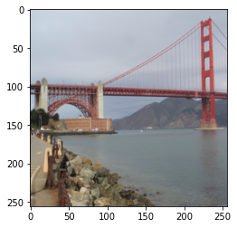

```python
import matplotlib.pyplot as plt

def suggest_locations(img_path):
    # get landmark predictions
    predicted_landmarks = predict_landmarks(img_path, 3)

    with Image.open(img_path) as image:
        resized = image.resize((256, 256))
        inp = np.asarray(resized)

        plt.imshow(inp)

        print('Is this picture of the {}, {}, or {}?'.format(*predicted_landmarks))

# test on a sample image
suggest_locations('images/test/09.Golden_Gate_Bridge/190f3bae17c32c37.jpg')
```

### (IMPLEMENTATION) Test Your Algorithm

Test your algorithm by running the `suggest_locations` function on at least four images on your computer. Feel free to use any images you like.

**Question 4:** Is the output better than you expected :) ? Or worse :( ? Provide at least three possible points of improvement for your algorithm.

I would suggest the following points of improvement for my algorithm:

- Regarding the transfer model, I would like to let it run for more epochs. I trained it for only 6 epochs and still the validation error kept decreasing, so it needed a couple of more epochs to reach the turning point where it would start overfitting with the training data. Note that, for the scratch model, it already had reached this point during training.
- Regarding the scratch model, I would love to add even more convolutional layers (potentially making it more similar to vgg19 in form), but it would require much more computation resources that what I had available in order to train well enough in a reasonable timefrae.
- One more point I would like to imporove is to use efficient transforms in order to increase the accuracy of the models. In particular, I would like to play arount by adding different transforms and tweaking their parameters (like for example the angle of the rotation) and train the models independently with each combination and record the performance of them. This way, I could hopefully find a good enough transforms combination that could help increase the accuracy of them models as much as possible.
- Same thing the learning rate and I would also like to test other optimezers (besides SGD and Adam) to see if they would yield better results. By the way, Adam performs very poorly on this task, as it fails on reducing the validation and test losses even the slightest.

```
Is this picture of the Eiffel_Tower, Terminal_Tower, or Temple_of_Heaven?
```

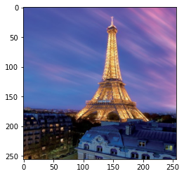

```python
## TODO: Execute the `suggest_locations` function on
## at least 4 images on your computer.
## Feel free to use as many code cells as needed.
suggest_locations('my_images/Eiffel_Tower.jpeg')
```

```
Is this picture of the Great_Wall_of_China, Edinburgh_Castle, or Eiffel_Tower?
```

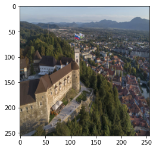

```python
suggest_locations('my_images/Ljubljana_Castle.jpeg')
```

```
Is this picture of the Grand_Canyon, Badlands_National_Park, or Great_Wall_of_China?
```

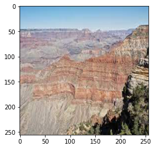

```python
suggest_locations('my_images/Grand_Canyon.jpeg')
```

```
Is this picture of the Sydney_Harbour_Bridge, Forth_Bridge, or Sydney_Opera_House?
```

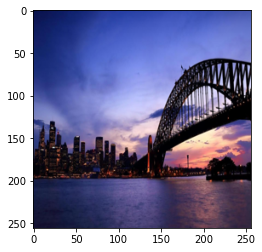

```python
suggest_locations('my_images/Sydney_Harbour_Bridge.jpeg')
```